## Pre-Processing

```r
# clear work space
rm(list=ls())
# Make code visible
echo = TRUE
# No scientific notations for numbers
options(scipen = 1)
```

## Loading and preprocessing the data

#### Step 1a: Loading data and convert date in activity data frame to date clss

```r
activity <- read.csv("./repdata-data-activity/activity.csv")
activity$date <- as.Date(activity$date)
```

#### Step 1b: Convert data frame to tbl class

```r
library(dplyr)
activity <- tbl_df(activity)
```

## What is mean total number of steps taken per day?

#### For this part of the assignment, you can ignore the missing values in the dataset.

#### Step 2a: Calculate Mean Total Number of Steps Taken Per Day

```r
activityStepsDay <- activity %>%
                    group_by(date) %>%
                    summarise(stepsSum = sum(steps))
```

#### Step 2b: Histogram of total number of steps taken each day

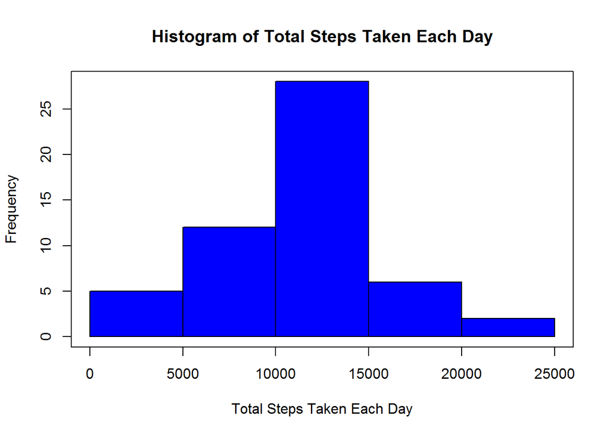

```r
hist(activityStepsDay$stepsSum, breaks = 5, freq = TRUE, main = "Histogram of Total Steps Taken Each Day", xlab= "Total Steps Taken Each Day", ylab = "Frequency", col="blue", border="black")
box(lty="solid")
```

#### Step2c: Report Mean of Total Steps Taken Each Day

```r
mean((activityStepsDay$stepsSum), na.rm=TRUE)
```

```
## [1] 10766.19
```

#### Step2d: Report Median of Total Steps Taken Each Day

```r
median((activityStepsDay$stepsSum), na.rm=TRUE)
```

```
## [1] 10765
```

## What is the average daily activity pattern?

#### Step 3a: Time Series Plot of Interval Vs Avg Number of Steps Taken averaged across all days

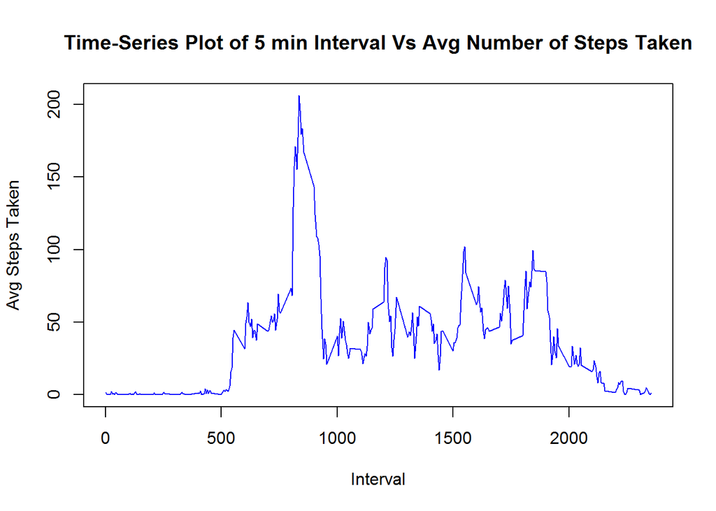

```r
activityIntervalAvg <- tapply(activity$steps, activity$interval, mean, na.rm=TRUE)

plot(row.names(activityIntervalAvg), activityIntervalAvg, type="l", main="Time-Series Plot of 5 min Interval Vs Avg Number of Steps Taken", xlab="Interval",ylab="Avg Steps Taken", col="blue")
```

#### Step 3b: The Time Interval at Which Maximum Number of Steps occurred when avg across all days

```r
names(which.max(activityIntervalAvg))
```

```
## [1] "835"
```

## Imputing missing values

#### Step 4a: Calculate and report total number of missing values (NAs)

```r
sum(is.na(activity$steps))
```

```
## [1] 2304
```

#### Step4b: Strategy for filling missing values

I have followed the strategy of imputing the NA values by the mean of steps for each interval taken across all days.

```r
#First calculate a data fram having the avg steps taken for each interval
activity$intervalasfac<- as.factor(activity$interval)
activityStepsInterval <- activity %>%
                         group_by(intervalasfac) %>%
                         summarise(Stepsavg = mean(steps,na.rm=TRUE))

#Next merge the data frame with activity data frame by grouping based on interval
activityImputed <- merge(activity,activityStepsInterval,by="intervalasfac")

#Then add a variable that has steps from activity & has mean steps values for NAs
activityImputed$stepsImputed <- ifelse(is.na(activityImputed$steps), activityImputed$Stepsavg, activityImputed$steps)
```

#### Step4c: create a new data set with missing data filled in

```r
activity2 <- activityImputed
activity2$steps <- activityImputed$stepsImputed
activity2$intervalasfac <- NULL
activity2$stepsImputed <- NULL
# check if any more NAs are present
sum(is.na(activity2$steps))
```

```
## [1] 0
```

#### Step4d: Histogram of total number of steps taken each day & mean, median calculation

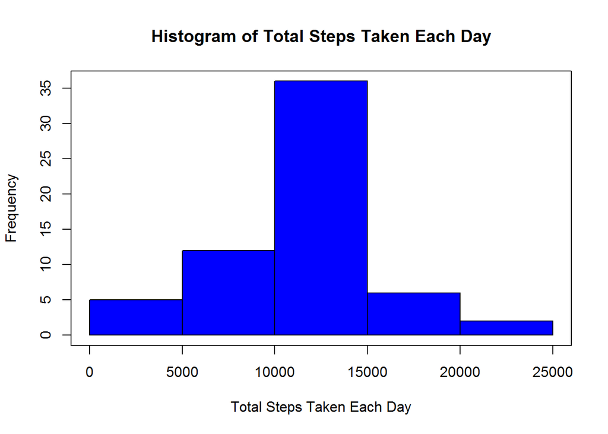

```r
activity2StepsDay <-activity2 %>%
                    group_by(date) %>%
                    summarise(stepsSum2 = sum(steps))

hist(activity2StepsDay$stepsSum, breaks = 5, freq = TRUE, main = "Histogram of Total Steps Taken Each Day", xlab= "Total Steps Taken Each Day", ylab = "Frequency", col="blue", border="black")
box(lty="solid")
```

```r
mean(activity2StepsDay$stepsSum2)
```

```
## [1] 10766.19
```

```r
median(activity2StepsDay$stepsSum2)
```

```
## [1] 10766.19
```

#### After imputing the missing NAs with the mean steps over each interval there is no effect on mean & median of total number of steps in each day. This approach doesnt effect the statistical results of the data set

## Are there differences in activity patterns between weekdays and weekends?

#### Step 5a:Create a new factor variable in the dataset with two levels - “weekday” and “weekend” indicating whether a given date is a weekday or weekend day.

```r
dayofweek <- weekdays(activity2$date)
dayfactor <- vector()
for (i in 1:nrow(activity2)) {
    if (dayofweek[i] == "Saturday" | dayofweek[i]=="Sunday") {
        dayfactor[i] <- "Weekend"
    } else {
        dayfactor[i] <- "Weekday"
    }
}

activity2$dayfactor <- as.factor(dayfactor)
```

#### Step 5b: Make a panel plot containing a time series plot (i.e. type = “l”) of the 5-minute interval (x-axis) and the average number of steps taken

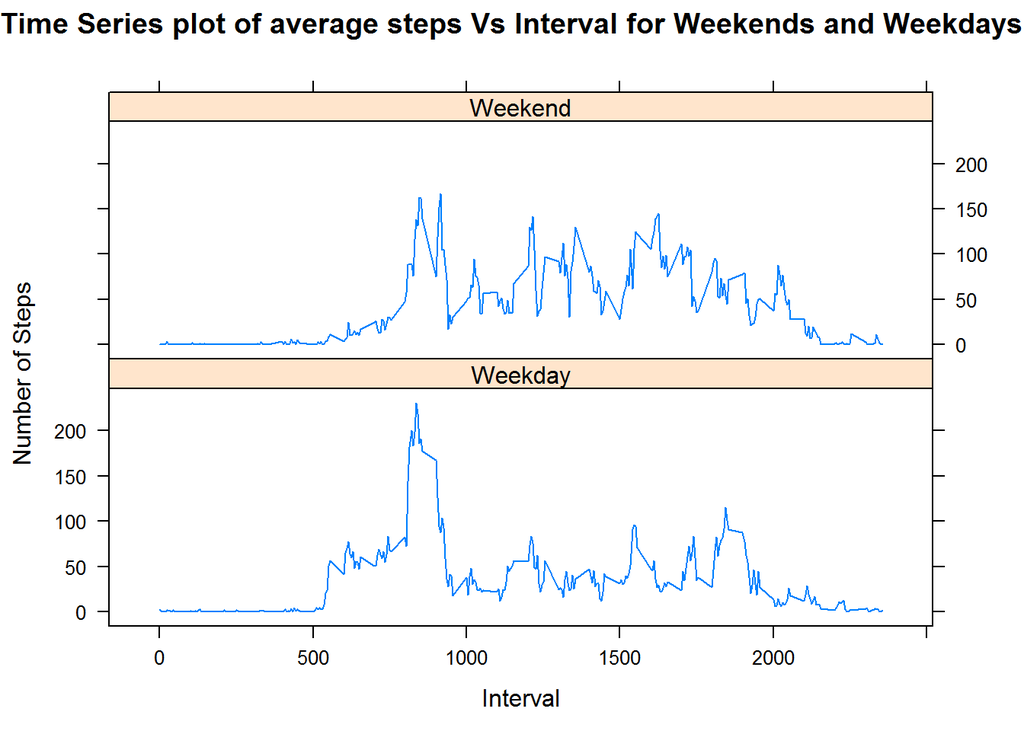

```r
activity2IntervaldayfactorAvg <- activity2 %>%
  group_by(dayfactor,interval) %>%
  summarise(Steps2avg = mean(steps))

library(ggplot2)
library(lattice)
xyplot(Steps2avg ~ interval | dayfactor, data = activity2IntervaldayfactorAvg,
       type = "l", layout = c(1,2), xlab = "Interval", ylab = "Number of Steps",
       main = "Time Series plot of average steps Vs Interval for Weekends and Weekdays")
```